# Predicting Activity using Weight Lifting Exercise Dataset

Michelle O

March 11, 2016

## Project Overview

This report will use data from accelerometers on the belt, forearm, arm, and dumbell of 6 participants to predict the manner in which they did barbell lifts. The individuals were asked to perform barbell lifts correctly and incorrectly in 5 different ways. The goal is to predict which of the 5 ways the barbell lifts were performed using measurements from the accelerometers. The 5 ways are represented by the “classe” variable within the training data. They have values “A”, which is the correct way to lift and “B”, “C”, “D”, “E”, which are the incorrect way to lift.

## Weight Lifting Exercises Dataset Source

The training data for this project are available here: https://d396qusza40orc.cloudfront.net/predmachlearn/pml-training.csv

The test data are available here: https://d396qusza40orc.cloudfront.net/predmachlearn/pml-testing.csv

The data for this project come from this source: http://groupware.les.inf.puc-rio.br/har

## Exploratory data analysis

We load the training and testing data set into R. Both data sets have 160 variables. Histogram shows the distribution of classe.

```r
trainingData<-read.csv(file = "C:/Users/moctovia/OneDrive/Dev Training/Documents/COursera/Practical Machine Learning/CourseProject - Activity Data/pml-training.csv")

testingData<-read.csv(file = "C:/Users/moctovia/OneDrive/Dev Training/Documents/COursera/Practical Machine Learning/CourseProject - Activity Data/pml-testing.csv")

dim(trainingData) # 160 variables
```

```
## [1] 19622   160
```

```r
dim(testingData)
```

```
## [1]  20 160
```

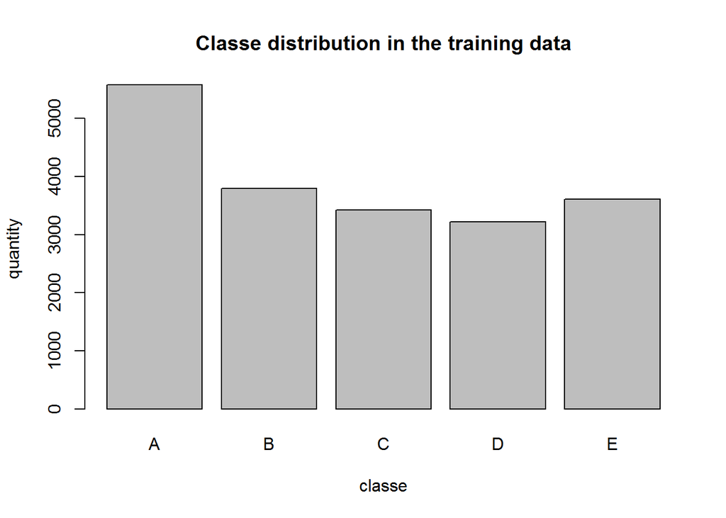

```r
barplot(table(trainingData$classe), xlab="classe", ylab="quantity", main="Classe distribution in the training data")
```

## Preprocessing

Summary of the dataset shows that there invalid and empty strings. We replace these invalid values to NA in both test and train data sets

```r
# Replace any #DIV/0, "NA" and empty strings as NA
trainingData[trainingData==""]<-NA
trainingData[trainingData=="#DIV/0!"]<-NA
trainingData[trainingData=="NA"]<-NA

testingData[testingData==""]<-NA
testingData[testingData=="#DIV/0!"]<-NA
testingData[testingData=="NA"]<-NA
```

Next, we remove the first 7 variables, which are identifiers and timestamps, and are not measurements of the activity.

```r
drop<-c("X", "user_name","raw_timestamp_part_1", "raw_timestamp_part_2",
                                 "cvtd_timestamp","new_window","num_window")
trainingData1<-trainingData[,!names(trainingData)%in% drop]
testingData1<-testingData[,!names(testingData)%in% drop]
```

## Predictor Selection

We will only use variables that are related to the raw measurements of the sensors. These variables appear with the following name patterns in the dataset: gyros_xxx_x|y|z, accel_xxx_x|y|z, total_accel_xxx, magnet_xxx_x|y|z, roll|pitch|yaw_xxx.

I used only data with the above column names. We have filtered the number of predictors down to 52.

```r
predictors <- c(grep("^accel", names(trainingData1)), grep("^gyros", names(trainingData1)), grep("^magnet", names(trainingData1)), grep("^roll", names(trainingData1)), grep("^pitch", names(trainingData1)), grep("^yaw", names(trainingData1)), grep("^total", names(trainingData1)))
trainingData2 <- trainingData1[, c(predictors, 153)]
testingData2 <- testingData1[, c(predictors, 153)]
```

Variables with near zero variance will not be considered as predictors. All 52 selected have nzv far from zero.

```r
library(caret)
```

```r
library(ggplot2)
library(randomForest)
nsv<-nearZeroVar(trainingData2, saveMetrics = TRUE, names = FALSE)
nsv
```

```
##                      freqRatio percentUnique zeroVar   nzv
## accel_belt_x          1.055412     0.8357966   FALSE FALSE
## accel_belt_y          1.113725     0.7287738   FALSE FALSE
## accel_belt_z          1.078767     1.5237998   FALSE FALSE
## accel_arm_x           1.017341     3.9598410   FALSE FALSE
## accel_arm_y           1.140187     2.7367241   FALSE FALSE
## accel_arm_z           1.128000     4.0362858   FALSE FALSE
## accel_dumbbell_x      1.018018     2.1659362   FALSE FALSE
## accel_dumbbell_y      1.053061     2.3748853   FALSE FALSE
## accel_dumbbell_z      1.133333     2.0894914   FALSE FALSE
## accel_forearm_x       1.126437     4.0464784   FALSE FALSE
## accel_forearm_y       1.059406     5.1116094   FALSE FALSE
## accel_forearm_z       1.006250     2.9558659   FALSE FALSE
## gyros_belt_x          1.058651     0.7134849   FALSE FALSE
## gyros_belt_y          1.144000     0.3516461   FALSE FALSE
## gyros_belt_z          1.066214     0.8612782   FALSE FALSE
## gyros_arm_x           1.015504     3.2769341   FALSE FALSE
## gyros_arm_y           1.454369     1.9162165   FALSE FALSE
## gyros_arm_z           1.110687     1.2638875   FALSE FALSE
## gyros_dumbbell_x      1.003268     1.2282132   FALSE FALSE
## gyros_dumbbell_y      1.264957     1.4167771   FALSE FALSE
## gyros_dumbbell_z      1.060100     1.0498420   FALSE FALSE
## gyros_forearm_x       1.059273     1.5187035   FALSE FALSE
## gyros_forearm_y       1.036554     3.7763735   FALSE FALSE
## gyros_forearm_z       1.122917     1.5645704   FALSE FALSE
## magnet_belt_x         1.090141     1.6664968   FALSE FALSE
## magnet_belt_y         1.099688     1.5187035   FALSE FALSE
## magnet_belt_z         1.006369     2.3290184   FALSE FALSE
## magnet_arm_x          1.000000     6.8239731   FALSE FALSE
## magnet_arm_y          1.056818     4.4439914   FALSE FALSE
## magnet_arm_z          1.036364     6.4468454   FALSE FALSE
## magnet_dumbbell_x     1.098266     5.7486495   FALSE FALSE
## magnet_dumbbell_y     1.197740     4.3012945   FALSE FALSE
## magnet_dumbbell_z     1.020833     3.4451126   FALSE FALSE
## magnet_forearm_x      1.012346     7.7667924   FALSE FALSE
## magnet_forearm_y      1.246914     9.5403119   FALSE FALSE
## magnet_forearm_z      1.000000     8.5771073   FALSE FALSE
## roll_belt             1.101904     6.7781062   FALSE FALSE
## roll_arm             52.338462    13.5256345   FALSE FALSE
## roll_dumbbell         1.022388    84.2065029   FALSE FALSE
## roll_forearm         11.589286    11.0895933   FALSE FALSE
## pitch_belt            1.036082     9.3772296   FALSE FALSE
## pitch_arm            87.256410    15.7323412   FALSE FALSE
## pitch_dumbbell        2.277372    81.7449801   FALSE FALSE
## pitch_forearm        65.983051    14.8557741   FALSE FALSE
## yaw_belt              1.058480     9.9734991   FALSE FALSE
## yaw_arm              33.029126    14.6570176   FALSE FALSE
## yaw_dumbbell          1.132231    83.4828254   FALSE FALSE
## yaw_forearm          15.322835    10.1467740   FALSE FALSE
## total_accel_belt      1.063160     0.1477933   FALSE FALSE
## total_accel_arm       1.024526     0.3363572   FALSE FALSE
## total_accel_dumbbell  1.072634     0.2191418   FALSE FALSE
## total_accel_forearm   1.128928     0.3567424   FALSE FALSE
## classe                1.469581     0.0254816   FALSE FALSE
```

## Cross Validation

I split 75% of the trainingData2 data into a training data set and the remaining 25% into a validation data set. The models will be trained using the new training subset.

```r
inTrain<-createDataPartition(y = trainingData2$classe, p = 0.75, list = FALSE)
training<-trainingData2[inTrain,]
validation<-trainingData2[-inTrain,]
trControl = trainControl(method = "cv", number = 4, allowParallel =TRUE);
```

## Model Building

Set up parallel processing to improve speed.

```r
library(doParallel);
rCluster <- makePSOCKcluster(4);
registerDoParallel(rCluster);
```

I built models using random forest and gradient boosting machine methods. The 2 models are cross validated using the validation data set.

```r
set.seed(125)
modFitRF<-train(classe ~ ., data=training, method = "rf", trControl = trControl, ntree = 250)
modFitGBM<-train(classe~ ., data=training, method="gbm",trControl= trControl, verbose= FALSE)

predRF<-predict(modFitRF,newdata = validation)
predGBM<-predict(modFitGBM,validation)
```

## Evaluate Error Rates

Confusion Matrices are used to evaluate the accuracy of the 2 models. Random Forest’s Confusion Matrix:

```r
confusionMatrix(predRF, validation$classe)
```

```
## Confusion Matrix and Statistics
##
##           Reference
## Prediction    A    B    C    D    E
##          A 1395    7    0    0    0
##          B    0  939    3    0    0
##          C    0    3  852   18    1
##          D    0    0    0  786    2
##          E    0    0    0    0  898
##
## Overall Statistics
##
##                Accuracy : 0.9931
##                  95% CI : (0.9903, 0.9952)
##     No Information Rate : 0.2845
##     P-Value [Acc > NIR] : < 2.2e-16
##
##                   Kappa : 0.9912
##  Mcnemar's Test P-Value : NA
##
## Statistics by Class:
##
##                      Class: A Class: B Class: C Class: D Class: E
## Sensitivity            1.0000   0.9895   0.9965   0.9776   0.9967
## Specificity            0.9980   0.9992   0.9946   0.9995   1.0000
## Pos Pred Value         0.9950   0.9968   0.9748   0.9975   1.0000
## Neg Pred Value         1.0000   0.9975   0.9993   0.9956   0.9993
## Prevalence             0.2845   0.1935   0.1743   0.1639   0.1837
## Detection Rate         0.2845   0.1915   0.1737   0.1603   0.1831
## Detection Prevalence   0.2859   0.1921   0.1782   0.1607   0.1831
## Balanced Accuracy      0.9990   0.9944   0.9955   0.9886   0.9983
```

Gradient Boosting Machine’s Confusion Matrix:

```r
confusionMatrix(predGBM, validation$classe)
```

```
## Confusion Matrix and Statistics
##
##           Reference
## Prediction    A    B    C    D    E
##          A 1377   27    0    0    0
##          B   14  896   13    5   13
##          C    2   26  830   45    5
##          D    2    0   12  752    9
##          E    0    0    0    2  874
##
## Overall Statistics
##
##                Accuracy : 0.9643
##                  95% CI : (0.9587, 0.9693)
##     No Information Rate : 0.2845
##     P-Value [Acc > NIR] : < 2.2e-16
##
##                   Kappa : 0.9549
##  Mcnemar's Test P-Value : NA
##
## Statistics by Class:
##
##                      Class: A Class: B Class: C Class: D Class: E
## Sensitivity            0.9871   0.9442   0.9708   0.9353   0.9700
## Specificity            0.9923   0.9886   0.9807   0.9944   0.9995
## Pos Pred Value         0.9808   0.9522   0.9141   0.9703   0.9977
## Neg Pred Value         0.9949   0.9866   0.9937   0.9874   0.9933
## Prevalence             0.2845   0.1935   0.1743   0.1639   0.1837
## Detection Rate         0.2808   0.1827   0.1692   0.1533   0.1782
## Detection Prevalence   0.2863   0.1919   0.1852   0.1580   0.1786
## Balanced Accuracy      0.9897   0.9664   0.9757   0.9649   0.9848
```

Random Forest method yields a better accuracy (99%) than gradient boosting machine (96%). Based on these reasons, I will pick Random Forest to predict my testing data.

## Predicting Test Cases

I ran the testing dataset through the random forest model to predict the 20 test cases available in the test data. Results are as follows:

```r
predTestingRF<-predict(modFitRF,newdata = testingData2)
predTestingRF
```

```
##  [1] B A B A A E D B A A B C B A E E A B B B
## Levels: A B C D E
```